# Lecture Notes CIML2

Newton Day

2021-04-29

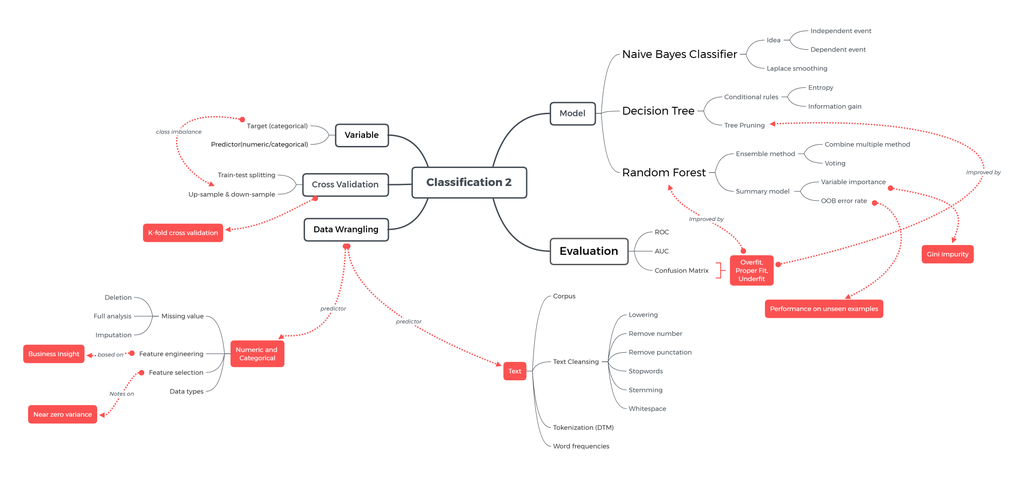

## Independent and Dependent Events

Dua kejadian disebut **INDEPENDENT** jika dua kejadian tersebut **tidak mempengaruhi secara langsung**

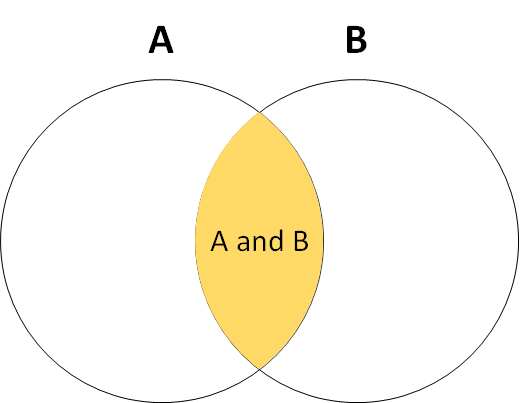

Indepenpent Event

- **Contoh Independent Event**:
  - Peluang dadu keluar angka 4 pada lemparan pertama **dan** peluang keluar angka 6 pada lemparan kedua
  - Peluang saya menaiki busway ke kantor dan peluang terjadi banjir di Tangerang
  - Peluang student Algoritma membeli jumpstart coffee dan peluang instruktor Algoritma membeli chicken karage

$$P(A \cap B) = P(A) \times P(B)$$

Dua kejadian disebut **DEPENDENT** jika dua kejadian tersebut **mempengaruhi secara langsung**. Probability dari dependent event biasa disebut juga dengan conditional probability. Yang mana merupakan landasan dari teorema bayes.

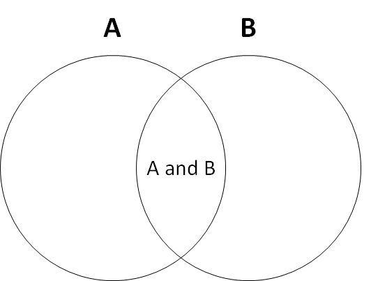

Dependent Event

- ** Contoh Dependent Event**:
  - Peluang banjir di Jakarta **jika diketahui** peluang hujan deras di Bogor
  - Peluang kelas Algoritma sepi jika diketahui peluang terjangkit COVID19 di daerah Jakarta
  - Peluang pelanggan memberi rating rendah jika diketahui terdapat kata “Buruk” pada form feedback

$$P(A|B) = \frac{P(B|A) P(A)}{P(B|A) P(A)\ +\ P(B|\neg A) P(\neg A)}$$

di mana:

$P(A|B)$ = Peluang terjadi A jika diketahui B telah terjadi.

$P(A)$ = Peluang terjadi A

$P(\neg A)$ = Peluang tidak terjadi A

## Naive Bayes

Naive Bayes adalah metode machine learning yang memanfaatkan Bayes Theorem untuk melakukan klasifikasi. Metode ini disebut **naive** karena mengasumsikan prediktor-prediktornya **independent** dan **sama penting**.

```r
library(e1071)

# model
votes_model <- naiveBayes(party ~ ., votes_train)
```

Advantages:  
Simple but powerful

Disadvantages:  
Skewness due to the data scarcity, di mana *salah satu prediktor kemunculannya 0 di salah satu kelas*

Remedies:  
- Menghapus variabel prediktor yang kemunculannya 0 di salah satu kelas  
- Melakukan laplace smoothing

## Laplace Smoothing

Menambahkan angka kecil pada kemunculan tiap prediktor agar peluang di suatu kelas tidak 0.

```r
votes_model <- naiveBayes(party ~ ., votes_train, laplace = 1)
```

## Text Mining

Text Mining merupakan salah satu teknik analisis data dan machine learning yang fokus utamanya adalah **mencari informasi dan pola-pola dari data yang tidak terstruktur**, yakni data teks. Data teks disebut tidak terstruktur karena:

- Dalam 1 kalimat bisa terdiri dari beberapa kata, yang jumlahnya berbeda-beda tiap kalimat.
- Adanya typo (salah ketik) dan penyingkatan kata (you menjadi u) sehingga perlu dibersihkan terlebih dahulu sebelum diproses.
- Adanya perbedaan bahasa yang digunakan sehingga perlu mencari lexicon yang cocok.
- Penggunaan simbol-simbol seperti #~!!$* yang mungkin tidak bermakna dan perlu dibersihkan

Secara umum, beberapa analisis yang bisa dihasilkan dari text mining serta workflow-nya secara general dapat digambarkan sebagai berikut:

[figure not shown]

## Text Mining using `tm`

### 1. Ubah data frame ke dalam corpus

```r
library(tm)
sms.corpus <- VCorpus(VectorSource(sms$text))
```

### 2. Text cleaning

Pada tahapan ini, urutan dan kebutuhan disesuaikan dengan kondisi teks

- Remove Numbers (menghapus angka)

```r
sms.corpus <- tm_map(sms.corpus, removeNumbers)
```

- Remove stopwords (menghapus kata-kata umum)

```r
# stopwords("en")
sms.corpus <- tm_map(sms.corpus, removeWords, stopwords("en"))
```

- Remove punctuations (menghapus tanda baca)

```r
sms.corpus <- tm_map(sms.corpus, removePunctuation)
```

- Stemming (mengubah ke kata dasar)

```r
# see how stemming works
library(SnowballC)
wordStem(c("kisses", "doing", "swimming", "sleeping"))

wordStem(c("ate", "slept", "broken"))

# stem words with `stemDocument`
sms.corpus <- tm_map(sms.corpus, stemDocument)
```

- Remove Extra White space

```r
sms.corpus <- tm_map(sms.corpus, stripWhitespace)
```

### 3. Tokenization

Mengubah kalimat menjadi perkata

```r
sms.dtm <- DocumentTermMatrix(sms.corpus)
inspect(sms.dtm)
```

## ROC dan AUC

As initial step, we need to take the probability of prediction.

```r
spam_pred_raw <- predict(model_sms, newdata = test_bn, type = "raw")
head(spam_pred_raw[,2])
```

As the requirement of ROC curve, we provide our model prediction and the actual class.

```r
spam_df <- data.frame("prediction" = spam_pred_raw[,2],
                      "true_class" = as.numeric(
                        ifelse(test_label == "spam", 1, 0)))
```

ROC curve is a plot of Sensitivity respect to Loss of Specificity given all possible threshold.

```r
library(ROCR)

# roc plot
spam_rocr <- ROCR::prediction(predictions = spam_df$prediction,
                              labels = spam_df$true_class)
performance <- ROCR::performance(spam_rocr, measure = "tpr", x.measure = "fpr")
plot(performance, colorize = T)

# auc
auc <- ROCR::performance(spam_rocr, "auc")
as.numeric(auc@y.values)
```

## Decision Tree

Decision tree (pohon keputusan) adalah metode klasifikasi yang **powerful**, **serbaguna** (antar prediktor dapat saling berkaitan), dan sangat **interpretable**. Decision tree bekerja dengan menyederhanakan rules/aturan dalam mengambil keputusan.

Struktur Decision Tree:

- **Root Node**: Node pertama/akar, berupa variabel yang paling utama digunakan untuk menentukan nilai target
- **Internal Node**: Node kedua/ranting dan seterusnya, berupa variabel lain yang digunakan apabila cabang pertama tidak cukup untuk menentukan target
- **Leaf/Terminal Node**: Nilai target atau kelas yang diprediksi

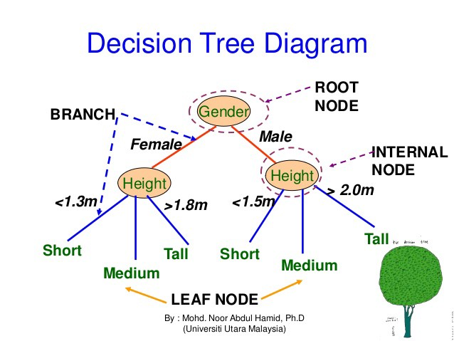

## Entropy dan Information Gain

Entropy dan Information gain merupakan perhitungan dibalik fungsi ctree untuk menentukan variabel apa yang akan menjai root dan internal node.

**1. Entropy**

Decision tree akan menghitung entropy (derajat kehomogenan) untuk target dan setiap prediktor dengan target. Entropy memiliki interval nilai antara 0 hingga log2(n), dimana n adalah banyaknya kelas target. Contoh:

Jika banyaknya kelas target biner (1/0), maka nilai entropy berada pada interval 0 sampai log2(2)= 1

Rumus Entropy:

$$Entropy = \Sigma_{i=1}^c -p_i \ log_2 \ p_i$$

Bila dipecah (entropy untuk target dengan dua kelas) menjadi:

$$Entropy = -\ p_1 \ log_2 \ p_1 -p_2 \ log_2 \ p_2$$

- $p_1$: proporsi kelas ke-*1* pada variabel **target**
- $p_2$: proporsi kelas ke-*2* pada variabel **target**

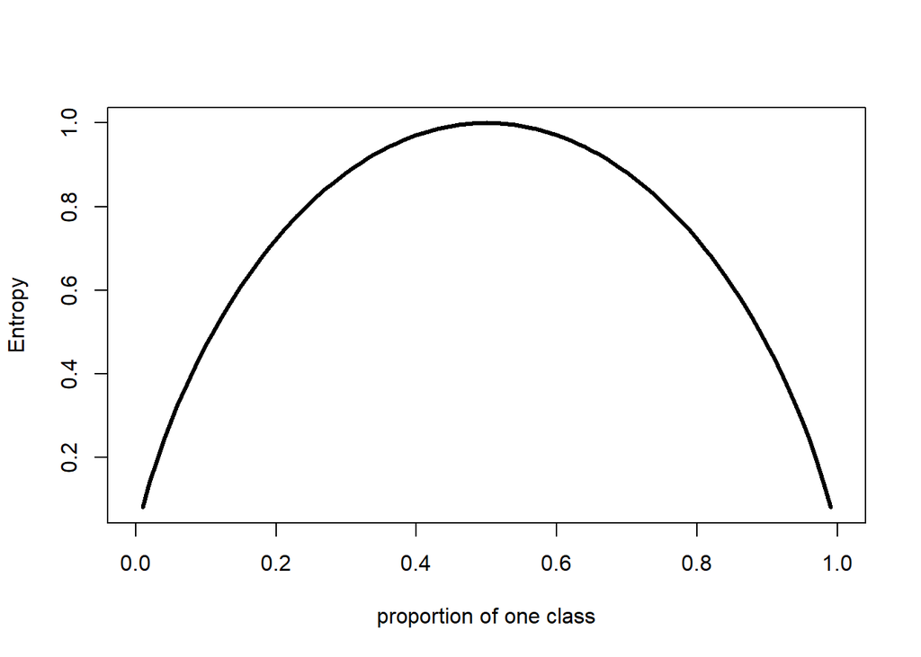

```r
curve(-x*log2(x) - (1-x)*log2(1-x), xlab="proportion of one class", ylab="Entropy", lwd=3)
```

Kemudian ditentukan variable prediktor yang mampu memberikan penurunan entropy paling besar atau menghasilkan information gain yang paling besar.

$$Information \ Gain = Entropy(parent) - (P_1 \ Entropy_1 + P_2 \ Entropy_2)$$

di mana:  
* $P_1$: proporsi kelas ke-*1* pada variabel **prediktor**  
* $P_2$: proporsi kelas ke-*2* pada variabel **prediktor**  
* $Entropy_1$: entropy untuk variabel prediktor pada kelas ke-1  
* $Entropy_2$: entropy untuk variabel prediktor pada kelas ke-2

### Contoh Komputasi

```r
dine <- read.csv("data_input/dineout.csv", sep = ";")
dine
```

```
##    Budget Distance    Friend Dine.Out
## 1    High      Far Available      Yes
## 2    High      Far    Absent       No
## 3     Low     Near    Absent       No
## 4    High     Near    Absent      Yes
## 5     Low      Far    Absent       No
## 6    High     Near    Absent      Yes
## 7     Low     Near Available       No
## 8     Low      Far Available       No
## 9     Low     Near Available       No
## 10   High      Far    Absent       No
## 11   High     Near Available      Yes
## 12    Low      Far    Absent       No
```

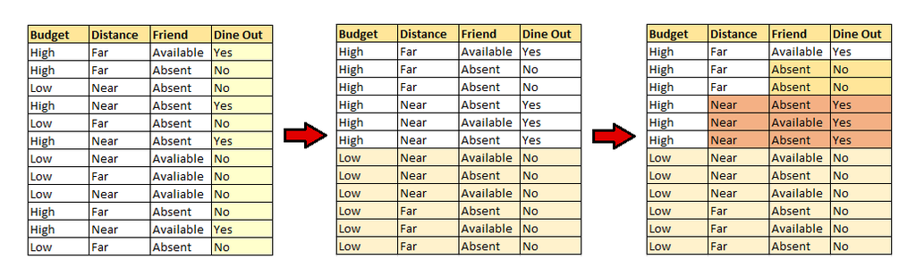

#### Menentukan Entropy dari Variabel Target

```r
entropy_awal <- - 8/12*log2(8/12) - 4/12*log2(4/12)
entropy_awal
```

```
## [1] 0.9182958
```

#### Menentukan Information gain dari tiap variabel prediktor

1. Contoh penghitungan information gain untuk variable `Budget`:

```r
table(budget = dine$Budget, dine = dine$Dine.Out)
```

```
##       dine
## budget No Yes
##   High  2   4
##   Low   6   0
```

```r
entropy_budget <- 6/12*(-2/6*log2(2/6) - 4/6*log2(4/6)) + # entropy Budget = High
                  6/12*(-6/6*log2(6/6)) # entropy Budget = Low
entropy_budget
```

```
## [1] 0.4591479
```

```r
ig_budget <- entropy_awal - entropy_budget
ig_budget
```

```
## [1] 0.4591479
```

2. Contoh penghitungan information gain untuk variable `Distance`:

```r
table(distance = dine$Distance, dine = dine$Dine.Out)
```

```
##         dine
## distance No Yes
##     Far   5   1
##     Near  3   3
```

```r
entropy_distance <- 6/12*(-5/6*log2(5/6) - 1/6*log2(1/6)) + # entropy Distance = Far
                  6/12*(-3/6*log2(3/6) - 3/6*log2(3/6)) # entropy Distance = Near
entropy_distance
```

```
## [1] 0.8250112
```

```r
ig_distance <- entropy_awal - entropy_distance
ig_distance
```

```
## [1] 0.09328462
```

3. Contoh penghitungan information gain untuk variable `Friend`:

```r
table(friend = dine$Friend, dine = dine$Dine.Out)
```

```
##            dine
## friend      No Yes
##   Absent     5   2
##   Available  3   2
```

```r
entropy_friend <- 7/12*(-5/7*log2(5/7) - 2/7*log2(2/7)) + # entropy Friend = Absent
                  5/12*(-3/5*log2(3/5) - 2/5*log2(2/5)) # entropy Friend = Available
entropy_friend
```

```
## [1] 0.9080497
```

```r
ig_friend <- entropy_awal - entropy_friend
ig_friend
```

```
## [1] 0.01024609
```

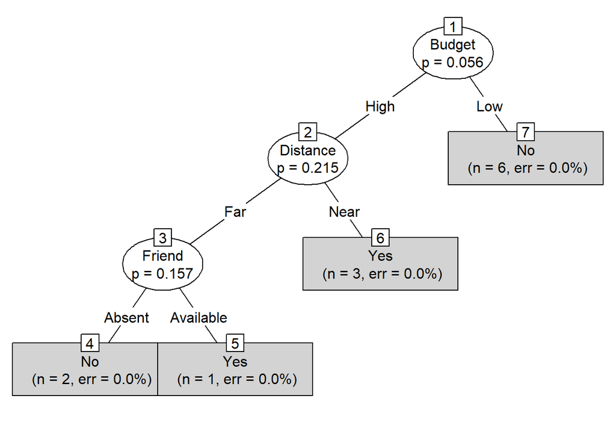

`Langkah-langkah dibalik pemodelan decision tree:` 1. Menghitung entropy target  
2. Menghitung entropy setiap prediktor dengan target  
3. Menghitung information gain setiap prediktor  
4. Memilih prediktor yang menghasilkan information gain *terbesar* 5. Split/bagi data berdasarkan prediktor tersebut  
6. Lakukan tahapan 2 hingga 5 untuk setiap node

### Pruning

Ketika membangun model decision tree, kita dapat menentukan seberapa kompleks rules yang dibentuk dengan melakukan pruning (membatasi pembentukan cabang pada pohon/menyederhanakan pohon yang dibentuk) untuk mencegah overfitting. Pruning dapat dilakukan dengan cara menambahkan parameter `control` pada saat melakukan pemodelan. Fungsi yang digunakan adalah `ctree_control()` dengan parameter:

- `mincriterion`: Nilainya adalah 1 - P-value. Bekerja sebagai “regulator” untuk kedalaman pohon. Semakin kecil nilainya maka semakin kompleks pohon yang dihasilkan. Misal mincriterion = 0.8, maka p-value < 0.2 yang digunakan untuk melakukan split/memecah node.
- `minsplit`: Jumlah observasi minimal pada pada node sebelum melakukan split. Misal minsplit = 50, maka node tersebut tidak akan dipecah jika observasi yang terdapat di dalam node < 50.
- `minbucket`: jumlah observasi minimal pada terminal node. Misal minbucket = 3, maka setiap terminal node yang terbentuk harus mempunyai minimal 3 observasi.

## Memahami Random Forest

Random Forest adalah salah satu jenis Ensemble Method. Random Forest melakukan prediksi dengan membuat sekumpulan banyak Decision Tree. Masing-masing Decision Tree memiliki karakteristik masing-masing dan tidak saling berhubungan satu sama lain. Random Forest kemudian melakukan prediksi untuk masing-masing decision tree, kemudian dari sekian banyak hasil prediksi tersebut dilakukan voting. Kelas dengan jumlah terbanyak akan menjadi hasil prediksi final. Random Forest memanfaatkan konsep bernama **Bagging: Bootstrap and Aggregation**. Berikut adalah proses yang terjadi:

1. Membuat data dengan random sampling dari data yang ada dan mengizinkan adanya duplikat (**Bootstrap sampling**)
2. Membuat decision tree dari masing-masing data hasil bootstrap sampling, digunakan prediktor sebanyak `mtry` yang juga dipilih secara random
3. Melakukan prediksi data baru untuk setiap decision tree
4. Melakukan majority voting untuk menentukan hasil prediksi final (**Aggregation**)

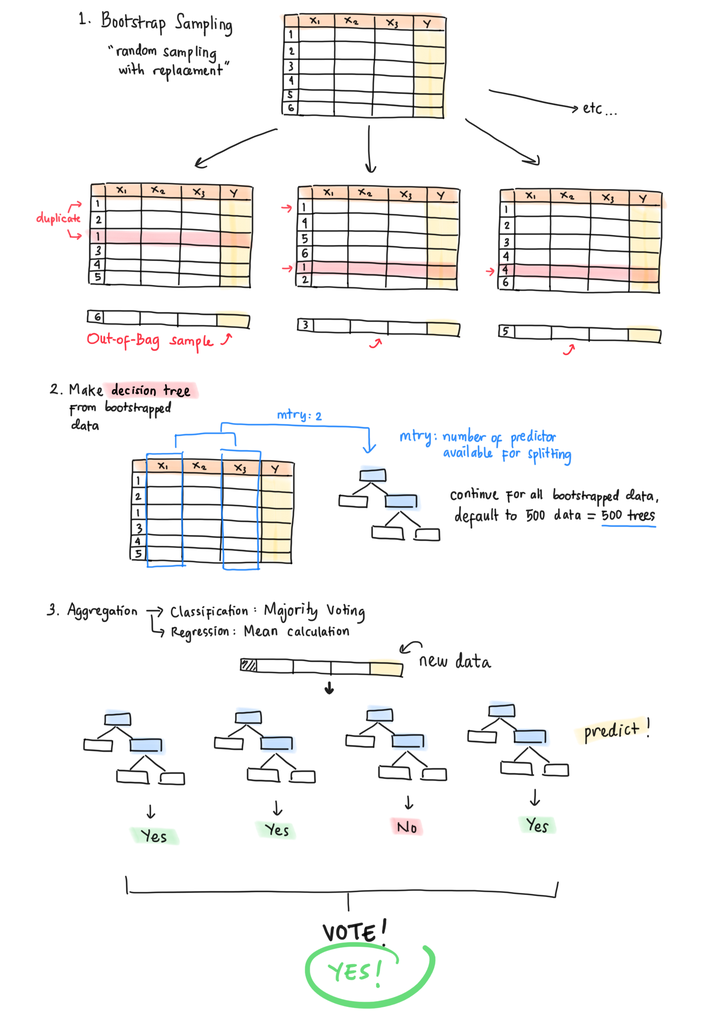

## K-Fold Cross Validation

Sebagai tambahan sebelum masuk ke study case untuk Random Forest, mari belajar 1 metode cross validasi tambahan yaitu k-fold cross validation. Cross validation biasa hanya membagi datanya menjadi `data_train` dan `data_test` secara tetap. **K-fold cross validation** akan membagi datanya sebanyak **k** bagian, setiap bagian akan digunakan menjadi data test secara bergantian.

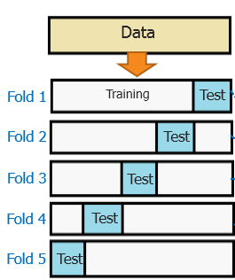

Further reading:

- [Ensemble Methods](https://towardsdatascience.com/ensemble-methods-bagging-boosting-and-stacking-c9214a10a205)
- [Bias Variance Tradeoff](https://towardsdatascience.com/understanding-the-bias-variance-tradeoff-165e6942b229)

Additional Links:

- [Text Summarization](https://github.com/ahmadhusain/covid19-dashboard)
- [Aplikasi Text Summarization](https://ahmadhusain.shinyapps.io/covid19-dashboard/)
- https://algotech.netlify.app/blog/text-generating-with-markov-chains/
- [https://algotech.netlify.app/blog/text-lstm/](https://algotech.netlify.app/blog/text-generating-with-markov-chains/)
- https://algotech.netlify.app/blog/text-cleaning-bahasa/
- https://github.com/onlyphantom/textmining/blob/master/processing.Rmd
- [Decision Tree](https://www.saedsayad.com/decision_tree.htm)
- [Binning in Decision Tree](https://www.saedsayad.com/supervised_binning.htm)
- [Stemming Bahasa Indonesia](https://github.com/nurandi/katadasaR)
- [Buku penggunaan tidytext package](https://www.tidytextmining.com/)
- [Dokumentasi library tm](https://cran.r-project.org/web/packages/tm/vignettes/tm.pdf)
- [Lemmatization](https://rdrr.io/cran/textstem/man/lemmatize_words.html)
- [Tidy Tet Mining](https://www.tidytextmining.com/)